# Biostat 203B Homework 2

Due Feb 12 @ 11:59PM

Valentina Arputhasamy

```r
knitr::opts_chunk$set(echo = TRUE, cache = TRUE)
library(tidyverse)
library(data.table)
library(lubridate)
library(dplyr)
library(ggthemes)
```

```r
os <- sessionInfo()$running
if (str_detect(os, "Linux")) {
  mimic_path <- "/usr/203b-data/mimic-iv"
} else if (str_detect(os, "macOS")) {
  mimic_path <- "/Users/huazhou/Documents/Box Sync/MIMIC/mimic-iv-0.4"
}
```

#Use tidyverse (ggpot2, dplyr) to explore the [MIMIC-IV](https://mimic-iv.mit.edu) data introduced in [homework #1](https://ucla-biostat203b-2021winter.github.io/hw/hw1/hw1.html).

```r
system(str_c("tree -s -L 2 ", shQuote(mimic_path)), intern = TRUE)
```

```
##  [1] "/usr/203b-data/mimic-iv"
##  [2] "├── [         78]  core"
##  [3] "│   ├── [   17224843]  admissions.csv.gz"
##  [4] "│   ├── [    2884996]  patients.csv.gz"
##  [5] "│   └── [   51188147]  transfers.csv.gz"
##  [6] "├── [       4096]  hosp"
##  [7] "│   ├── [     430049]  d_hcpcs.csv.gz"
##  [8] "│   ├── [   26575586]  diagnoses_icd.csv.gz"
##  [9] "│   ├── [     723633]  d_icd_diagnoses.csv.gz"
## [10] "│   ├── [     564422]  d_icd_procedures.csv.gz"
## [11] "│   ├── [      14845]  d_labitems.csv.gz"
## [12] "│   ├── [   12913088]  drgcodes.csv.gz"
## [13] "│   ├── [  518077567]  emar.csv.gz"
## [14] "│   ├── [  479709397]  emar_detail.csv.gz"
## [15] "│   ├── [    1415469]  hcpcsevents.csv.gz"
```

[output cut: 20 more lines]

## Q1. PhysioNet credential

At this moment, you should already get credentialed on the PhysioNet. Please include a screenshot of your `Data Use Agreement for the MIMIC-IV (v0.4)`.

## Q2. `read.csv` (base R) vs `read_csv` (tidyverse) vs `fread` (data.table)

There are quite a few utilities in R for reading data files. Let us test the speed of reading a moderate sized compressed csv file, `admissions.csv.gz`, by three programs: `read.csv` in base R, `read_csv` in tidyverse, and `fread` in the popular data.table package. Is there any speed difference?

In this homework, we stick to the tidyverse.

*Solution:*

After testing all three options, I found that `fread` read the file the quickest; it took about 4 seconds to read the file. The second quickest was `read_csv`, and took about 7 seconds. The slowest option was `read.csv`, which took 45 seconds to read the file (making it the slowest by quite a bit).

## Q3. ICU stays

`icustays.csv.gz` (https://mimic-iv.mit.edu/docs/datasets/icu/icustays/) contains data about Intensive Care Units (ICU) stays. Summarize following variables using appropriate numerics or graphs:

- how many unique `stay_id`?

There are 69,619 unique values for `stay_id`.

```r
setwd("/usr/203b-data/mimic-iv/icu")
icustays <- read_csv("icustays.csv.gz")
length(unique(icustays$stay_id))
```

```
## [1] 69619
```

- how many unique `subject_id`?

There are 50,048 unique values for `subject_id`.

```r
length(unique(icustays$subject_id))
```

```
## [1] 50048
```

- length of ICU stay

```r
icustays$intime <- ymd_hms(icustays$intime)

icustays$outtime <- ymd_hms(icustays$outtime)

icustays$stayduration <- log(as.double(difftime(icustays$outtime,
                                                icustays$intime,
                                                units = "days")))
```

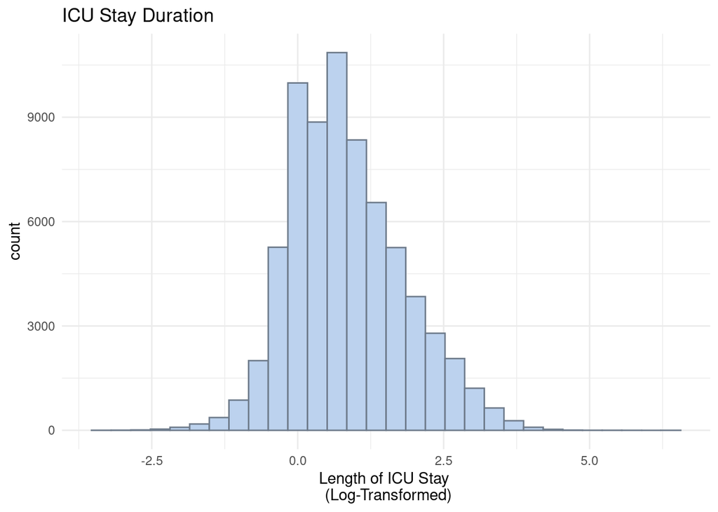

```r
icustays %>% ggplot(aes(stayduration)) +
  geom_histogram(fill = "lightsteelblue2", color = "lightsteelblue4") +
  theme_minimal() + ggtitle("ICU Stay Duration") +
  xlab("Length of ICU Stay \n (Log-Transformed)") + ylab("count")
```

- first ICU unit

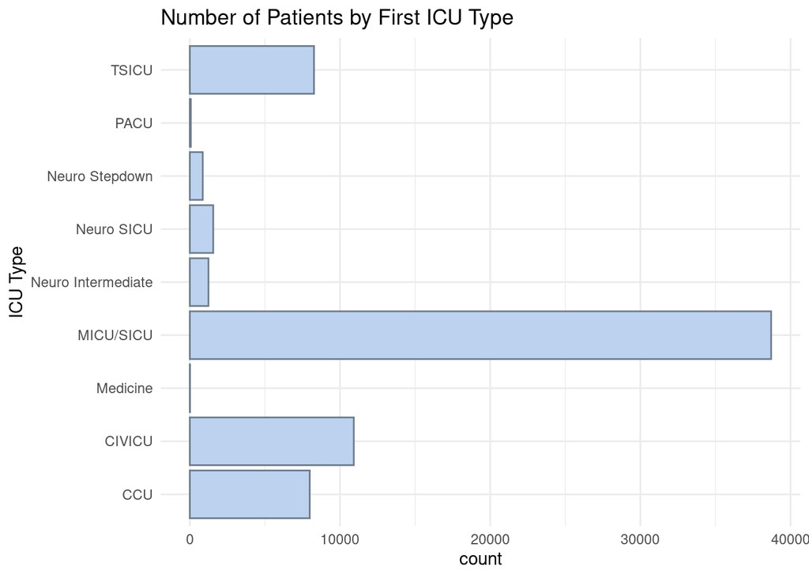

```r
icustays2 <- icustays
icustays2 <- icustays2 %>% mutate(first_careunit_recode = recode(first_careunit,
  "Coronary Care Unit (CCU)" = "CCU", "Trauma SICU (TSICU)" = "TSICU",
  "Surgical Intensive Care Unit (SICU)" = "MICU/SICU",
  "Medical/Surgical Intensive Care Unit (MICU/SICU)" = "MICU/SICU",
  "Medical Intensive Care Unit (MICU)" = "MICU/SICU",
  "Cardiac Vascular Intensive Care Unit (CVICU)" = "CIVICU",
  "Neuro Surgical Intensive Care Unit (Neuro SICU)" = "Neuro SICU"))

icustays2 %>% ggplot( aes(first_careunit_recode)) +
  geom_bar(fill = "lightsteelblue2", color = "lightsteelblue4") +
  theme_minimal() + ggtitle("Number of Patients by First ICU Type") +
  xlab("ICU Type") + ylab("count") + coord_flip()
```

- last ICU unit

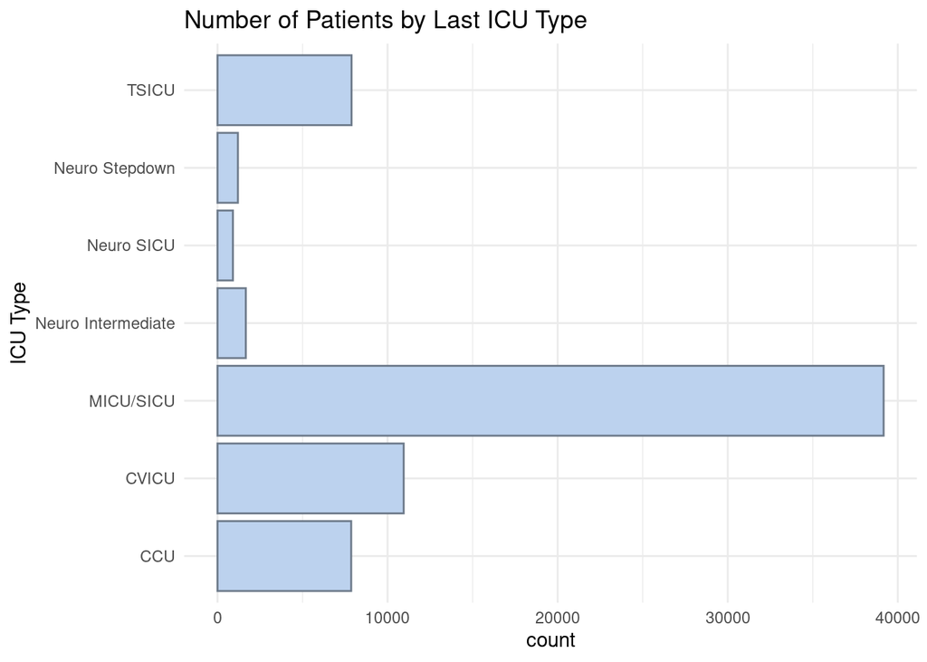

```r
icustays2 <- icustays2 %>% mutate(last_careunit_recode = recode(last_careunit,
"Coronary Care Unit (CCU)" = "CCU", "Trauma SICU (TSICU)" = "TSICU",
"Surgical Intensive Care Unit (SICU)" = "MICU/SICU",
"Medical/Surgical Intensive Care Unit (MICU/SICU)" = "MICU/SICU",
"Medical Intensive Care Unit (MICU)" = "MICU/SICU",
"Cardiac Vascular Intensive Care Unit (CVICU)" = "CVICU",
"Neuro Surgical Intensive Care Unit (Neuro SICU)" = "Neuro SICU"))

icustays2 %>% ggplot(aes(last_careunit_recode)) +
  geom_bar(fill = "lightsteelblue2", color = "lightsteelblue4") +
  theme_minimal() + ggtitle("Number of Patients by Last ICU Type") +
  xlab("ICU Type") + ylab("count") + coord_flip()
```

## Q4. `admission` data

Information of the patients admitted into hospital is available in `ADMISSION.csv.gz`. See https://mimic-iv.mit.edu/docs/datasets/core/admissions/ for details of each field in this file. Summarize following variables using appropriate graphs. Explain any patterns you observe.

- admission year
- admission month
- admission month day
- admission week day
- admission hour (anything unusual?)
- number of deaths in each year
- admission type
- number of admissions per patient
- admission location
- discharge location
- insurance
- language
- martial status
- ethnicity
- death

```r
setwd("/usr/203b-data/mimic-iv/core")
admissions <- read_csv("admissions.csv.gz")
```

### Admission Year

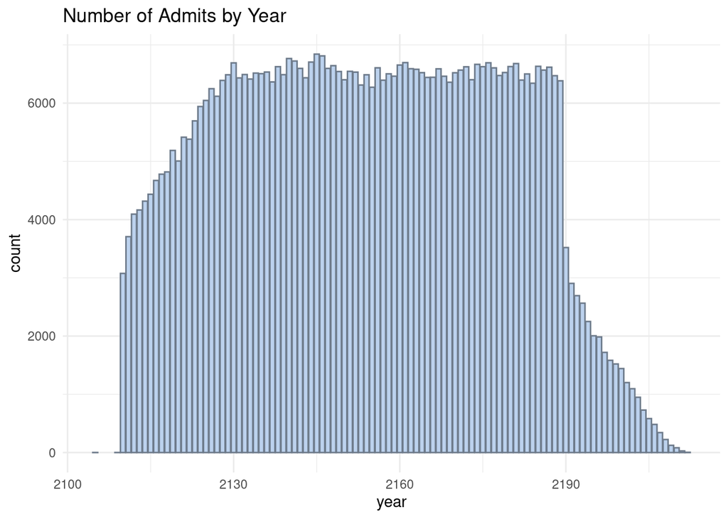

```r
admissions$admit_year <- year(admissions$admittime)

admissions %>% ggplot(aes(admit_year)) +
  geom_bar(binwidth = 1, fill = "lightsteelblue2", color = "lightsteelblue4") +
  ggtitle("Number of Admits by Year") + xlab("year") + theme_minimal()
```

### Admission Month

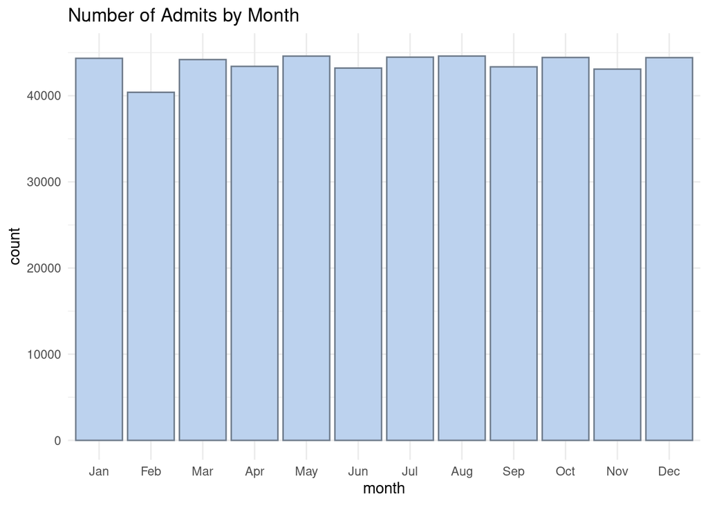

```r
admissions$admit_month <- month(admissions$admittime)

admissions2 <- admissions %>% mutate(admit_month_recode = recode(admit_month,
"1" = "Jan", "2" = "Feb", "3" = "Mar", "4" = "Apr", "5" = "May", "6" = "Jun",
"7" = "Jul", "8" = "Aug", "9" = "Sep", "10" = "Oct", "11" = "Nov",
"12" = "Dec"))

admissions2$admit_month_recode = factor(admissions2$admit_month_recode,
                                        levels = month.abb)

admissions2 %>% ggplot(aes(admit_month_recode)) +
  geom_bar(binwidth = 1, fill = "lightsteelblue2", color = "lightsteelblue4") +
  ggtitle("Number of Admits by Month") + xlab("month") + ylab("count") +
  scale_x_discrete() + theme_minimal() + ylim(c(0,45000))
```

### Admission Day of the Month

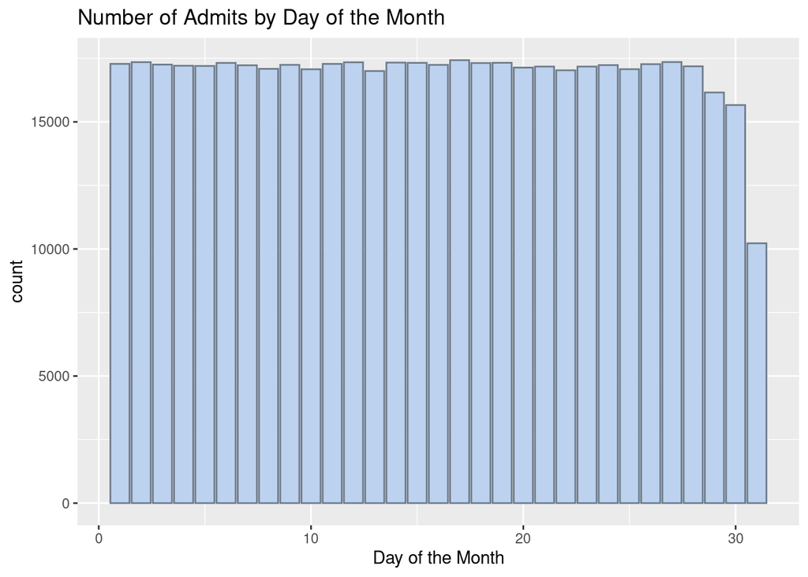

```r
admissions2$admit_date <- day(admissions2$admittime)

admissions2 %>% ggplot(aes(admit_date)) +
  geom_bar(binwidth = 1, fill = "lightsteelblue2", color = "lightsteelblue4") +
  ggtitle("Number of Admits by Day of the Month") + xlab("Day of the Month")
```

### Admissions Day of the Week

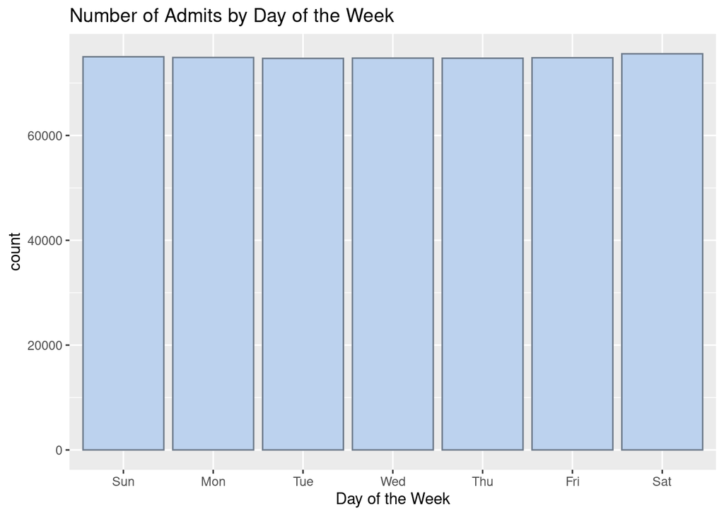

```r
admissions2$admit_dow <- wday(admissions2$admittime, label = T)

admissions2 %>% ggplot(aes(admit_dow)) +
  geom_bar(binwidth = 1, fill = "lightsteelblue2", color = "lightsteelblue4") +
  ggtitle("Number of Admits by Day of the Week") + xlab("Day of the Week")
```

### Admission Hour (what is unusual?)

Admission hour is distributed rather strangely, with many admissions occuring early in the morning or late at night.

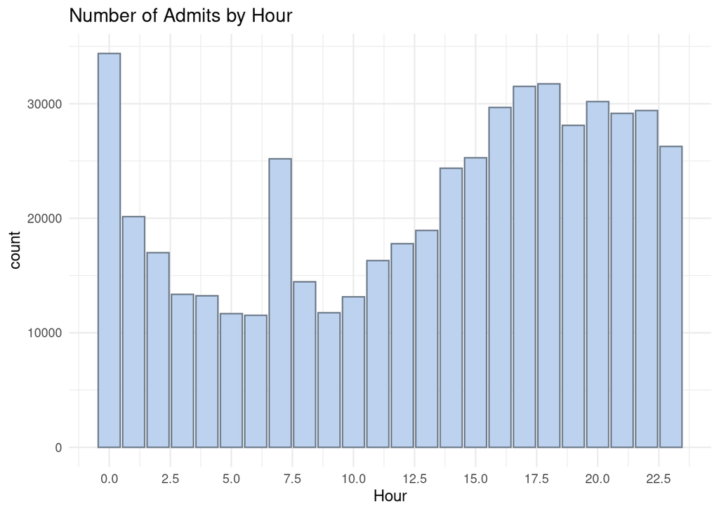

```r
admissions2$admit_hour <- hour(admissions2$admittime)

admissions2 %>% ggplot(aes(admit_hour)) +
  geom_bar(binwidth = 1, fill = "lightsteelblue2", color = "lightsteelblue4") +
  ggtitle("Number of Admits by Hour") + xlab("Hour") + theme_minimal() +
  scale_x_continuous(n.breaks = 10)
```

### Number of Deaths in Each Year

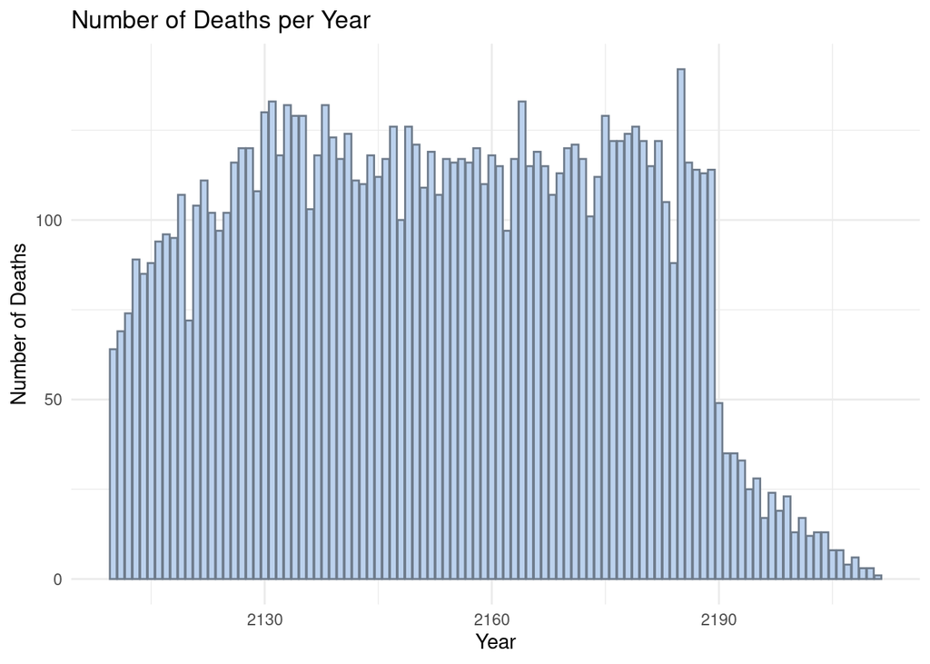

```r
admissions2$death_year <- year(admissions2$deathtime)

admissions2 %>% ggplot(aes(death_year)) +
  geom_bar(binwidth = 1, fill = "lightsteelblue2", color = "lightsteelblue4") +
  ggtitle("Number of Deaths per Year") + xlab("Year") +
  ylab("Number of Deaths") +theme_minimal()
```

### Admission Type

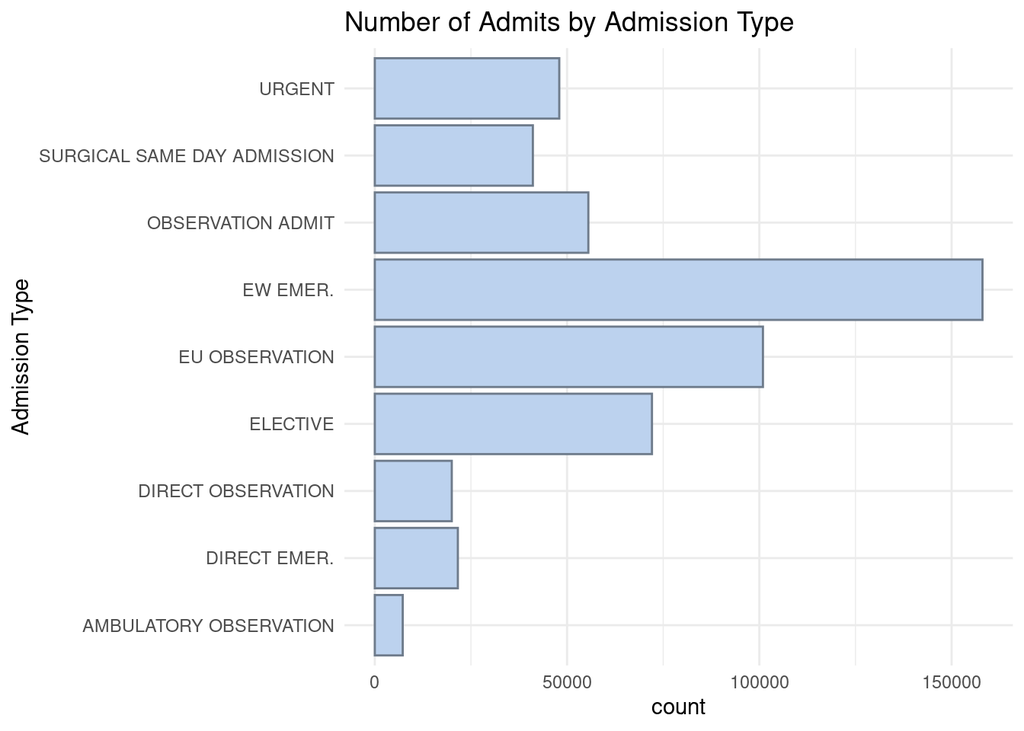

```r
admissions2 %>% ggplot(aes(admission_type)) +
  geom_bar(fill = "lightsteelblue2", color = "lightsteelblue4") +
  coord_flip() + ggtitle("Number of Admits by Admission Type") +
  xlab("Admission Type") + theme_minimal()
```

### Number of Admissions per Patient

```
## Storing counts in `nn`, as `n` already present in input
## ℹ Use `name = "new_name"` to pick a new name.
```

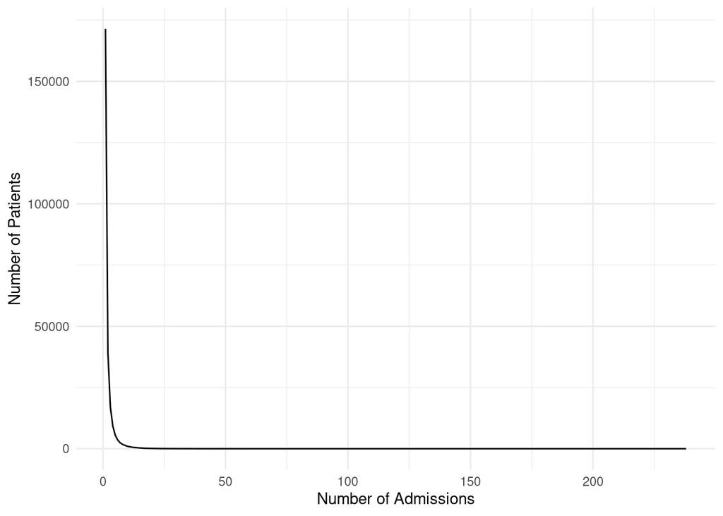

```r
nadmit.patient <- admissions2 %>% count(., subject_id)
nadmit.patient %>% count(.,n) %>% rename("Admit_Days" = "n",
                                         "Frequency" = "nn") %>%
  ggplot(aes(Admit_Days, Frequency)) + geom_line() +
  xlab("Number of Admissions") + ylab("Number of Patients") + theme_minimal()
```

### Admission Location

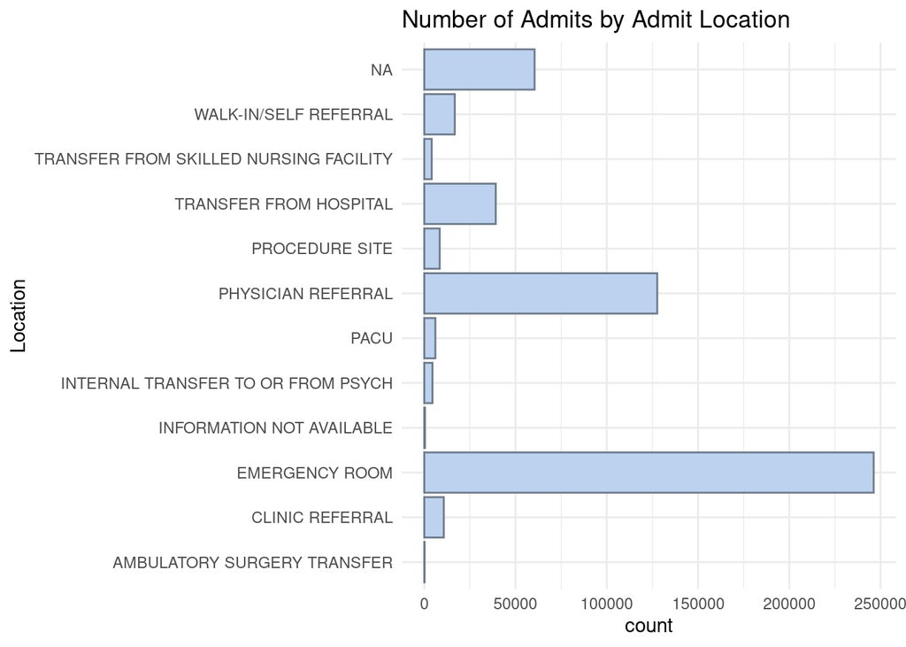

```r
admissions2 %>% ggplot(aes(admission_location)) +
  geom_bar(fill = "lightsteelblue2", color = "lightsteelblue4") +
  coord_flip() + ggtitle("Number of Admits by Admit Location") +
  xlab("Location") + theme_minimal()
```

### Discharge Location

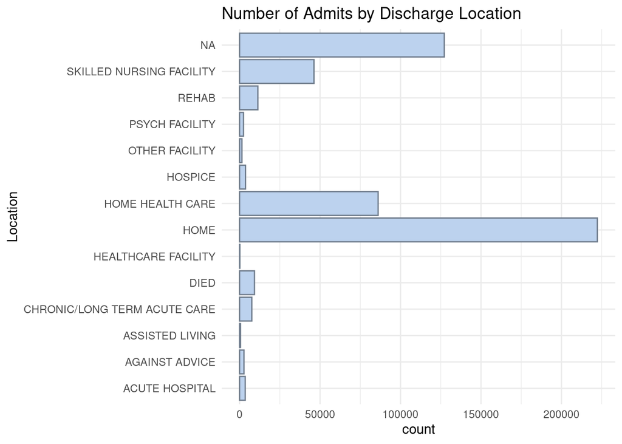

```r
admissions2 %>% ggplot(aes(discharge_location)) +
  geom_bar(fill = "lightsteelblue2", color = "lightsteelblue4") +
  coord_flip() + ggtitle("Number of Admits by Discharge Location") +
  xlab("Location") + theme_minimal()
```

### Insurance

For insurance, I thought it would make sense to summarize based on unique patients.

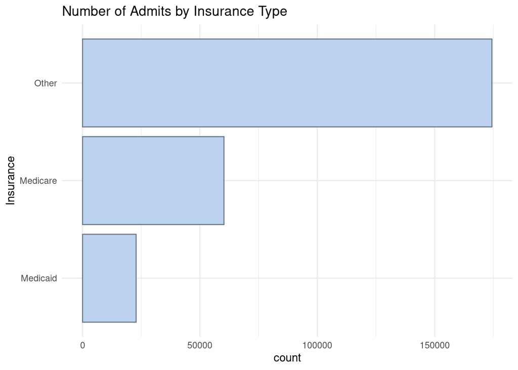

```r
admissions2 %>% distinct(subject_id, .keep_all = T) %>%
  ggplot(aes(insurance)) +
  geom_bar(fill = "lightsteelblue2", color = "lightsteelblue4") +
  coord_flip() + ggtitle("Number of Admits by Insurance Type") +
  xlab("Insurance") + theme_minimal()
```

### Language

For language, I thought it would make sense to summarize based on unique patients.

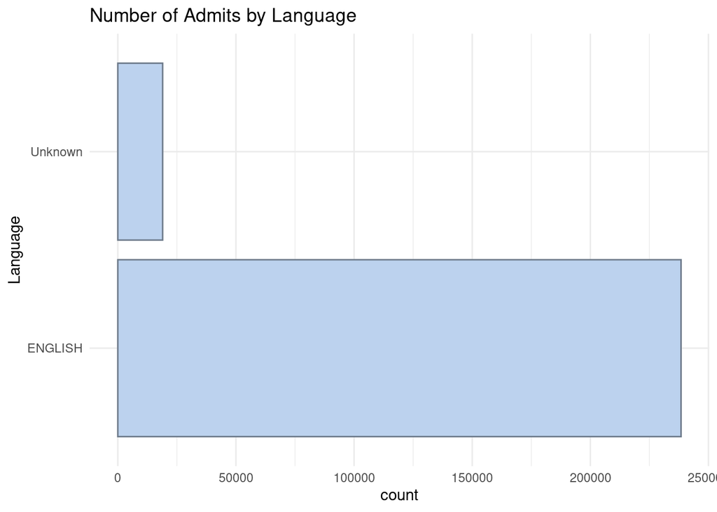

```r
admissions2 <- admissions2 %>% mutate(language_recode =
                                        recode(language, "?" = "Unknown"))

admissions2 %>% distinct(subject_id, .keep_all = T) %>%
  ggplot(aes(language_recode)) +
  geom_bar(fill = "lightsteelblue2", color = "lightsteelblue4") +
  coord_flip() + ggtitle("Number of Admits by Language") +
  xlab("Language") + theme_minimal()
```

### Marital Status

For marital status, I thought it would make sense to summarize based on unique patients.

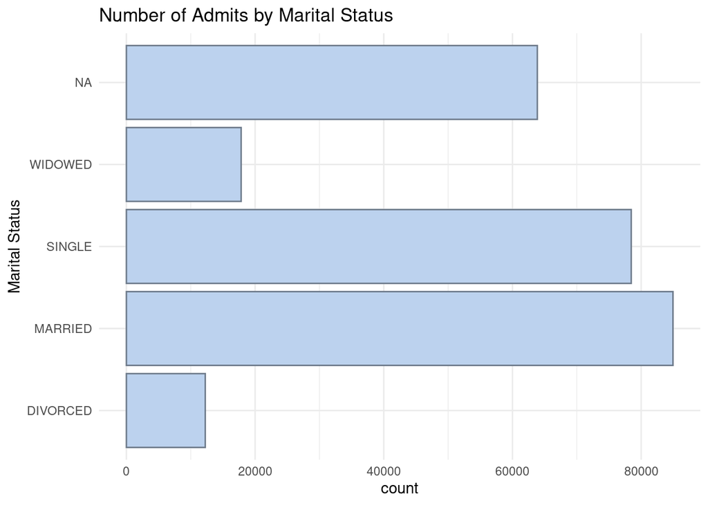

```r
admissions2 %>% distinct(subject_id, .keep_all = T) %>%
  ggplot(aes(marital_status)) +
  geom_bar(fill = "lightsteelblue2", color = "lightsteelblue4") +
  coord_flip() + ggtitle("Number of Admits by Marital Status") +
  xlab("Marital Status") + theme_minimal()
```

### Ethnicity

For ethnicity, I thought it would make sense to summarize based on unique patients.

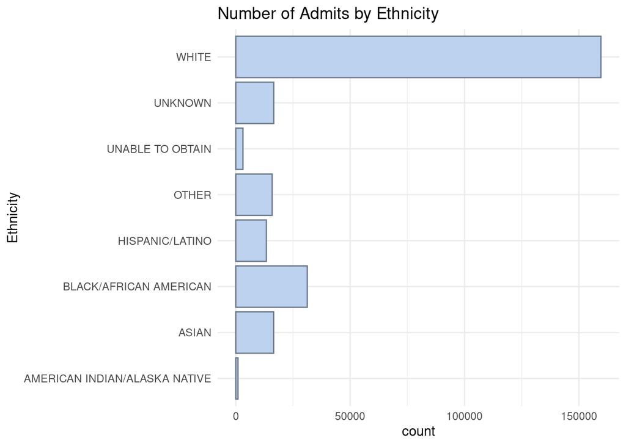

```r
admissions2 %>% distinct(subject_id, .keep_all = T) %>%
  ggplot(aes(ethnicity)) +
  geom_bar(fill = "lightsteelblue2", color = "lightsteelblue4") +
  coord_flip() + ggtitle("Number of Admits by Ethnicity") +
  xlab("Ethnicity") + theme_minimal()
```

### Deaths

For deaths, I thought it would make sense to summarize based on unique patients.

```r
admissions2$death_yn[is.na(admissions2$death_year)] <- 0
```

[figure not shown]

```r
admissions2$death_yn <- ifelse(admissions2$death_yn == 0, "Survived", "Died")

admissions2 %>% distinct(subject_id, .keep_all = T) %>% ggplot(aes(death_yn)) +
  geom_bar(fill = "lightsteelblue2", color = "lightsteelblue4") +
  ggtitle("Number of Deaths") + xlab("Survival Status") +
  theme_minimal() + scale_y_continuous()
```

## Q5. `patient` data

Explore `patients.csv.gz` (https://mimic-iv.mit.edu/docs/datasets/core/patients/) and summarize following variables using appropriate numerics and graphs:

- `gender`
- `anchor_age` (explain pattern you see)

```r
getwd()
```

```
## [1] "/home/valentina214/biostat-203b-2021-winter/hw2"
```

```r
setwd("/usr/203b-data/mimic-iv/core")
patients <- read_csv("patients.csv.gz")
```

### Gender

There are 200,226 female patients and 182,994 male patients.

```r
patients %>% count(.,gender)
```

```
## # A tibble: 2 x 2
##   gender      n
##   <chr>   <int>
## 1 F      200226
## 2 M      182994
```

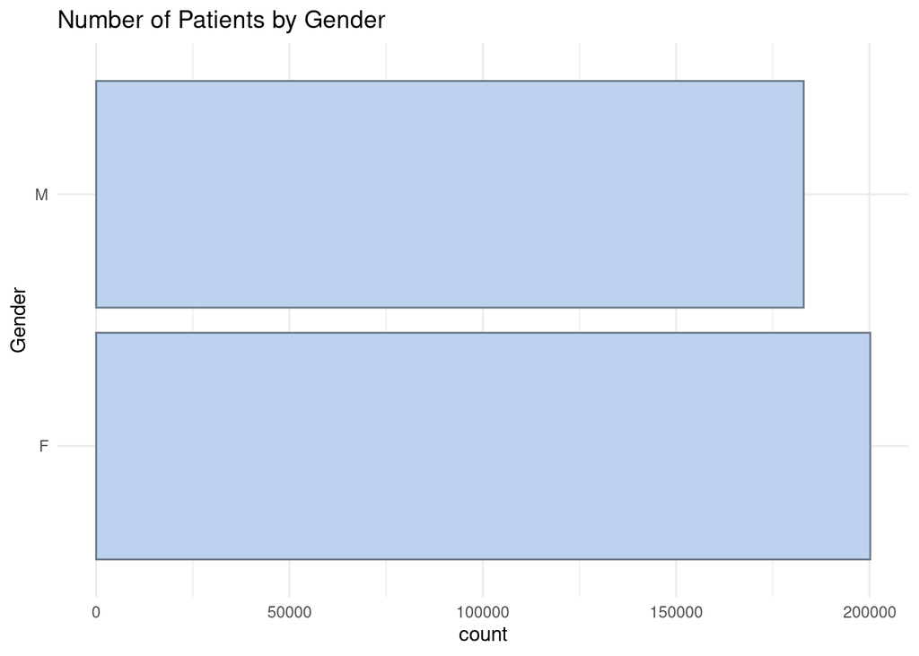

```r
patients %>% ggplot(aes(gender)) +
  geom_bar(fill = "lightsteelblue2", color = "lightsteelblue4") +
  coord_flip() + ggtitle("Number of Patients by Gender") +
  xlab("Gender") + theme_minimal()
```

### Anchor Age

0 is possibly for missing data. The median and mean anchor age is approximately 41.

```r
summary(patients$anchor_age)
```

```
##    Min. 1st Qu.  Median    Mean 3rd Qu.    Max.
##    0.00   22.00   41.00   40.95   62.00   91.00
```

[figure not shown]

```r
patients %>% ggplot(aes(anchor_age)) +
  geom_bar(binwidth = 1, fill = "lightsteelblue2", color = "lightsteelblue4") +
  ggtitle("Number of Patients by Gender") + xlab("Anchor Age") +theme_minimal()
```

## Q6. Lab results

`labevents.csv.gz` (https://mimic-iv.mit.edu/docs/datasets/hosp/labevents/) contains all laboratory measurements for patients.

We are interested in the lab measurements of creatinine (50912), potassium (50971), sodium (50983), chloride (50902), bicarbonate (50882), hematocrit (51221), white blood cell count (51301), glucose (50931), magnesium (50960), calcium (50893), and lactate (50813). Find the `itemids` of these lab measurements from `d_labitems.csv.gz` and retrieve a subset of `labevents.csv.gz` only containing these items.

```r
setwd("/usr/203b-data/mimic-iv-derived-data")
labevents <- fread("labevents_filtered_itemid.csv.gz",
                   col.names = c("subjectid", "hadmid", "itemid", "charttime",
                   "valuenum"))

want.id <- c(50912, 50971, 50983, 50902, 50882, 51221, 51301, 50931, 50960,
             50893, 50813)

labevents.want <- labevents %>% filter(itemid %in% want.id)
```

## Q7. Vitals from chartered events

We are interested in the vitals for ICU patients: heart rate, mean and systolic blood pressure (invasive and noninvasive measurements combined), body temperature, SpO2, and respiratory rate.

`chartevents.csv.gz` (https://mimic-iv.mit.edu/docs/datasets/icu/chartevents/) contains all the charted data available for a patient. During their ICU stay, the primary repository of a patient’s information is their electronic chart. The `ITEMID` variable indicates a single measurement type in the database. The `VALUE` variable is the value measured for `ITEMID`.

`d_items.csv.gz` (https://mimic-iv.mit.edu/docs/datasets/icu/d_items/) is the dictionary for the `ITEMID` in `CHARTEVENTS.csv`. Find potential values of `ITEMID` that correspond to systolic blood pressure, i.e., `LABEL` contains the string `systolic`.

```r
setwd("/usr/203b-data/mimic-iv-derived-data")
chart_events <- fread("chartevents_filtered_itemid.csv.gz")
```

```r
setwd("/usr/203b-data/mimic-iv/icu")
dictionary <- fread("d_items.csv.gz")
```

```r
#heart rate : 220045

dictionary$itemid[dictionary$label %in% c("Heart Rate",
                                          "Arterial Blood Pressure systolic",
                                          "Arterial Blood Pressure mean",
                                          "Non Invasive Blood Pressure systolic",
                                          "Non Invasive Blood Pressure mean",
                                          "Temperature Celsius",
                                          "Respiratory Rate",
                                          "PAR-Oxygen saturation")]
```

```
## [1] 220045 220050 220052 220179 220181 220210 223762 228232
```

```r
chart_events.want <- chart_events %>% filter(V5 %in% c(220045, 220050, 220052,
                                                       220179, 220181, 220210,
                                                       223762, 228232))

head(chart_events.want)
```

```
##          V1       V2       V3                  V4     V5  V6
## 1: 10003700 28623837 35053963 2165-04-24 05:28:00 220179 152
## 2: 10003700 28623837 35053963 2165-04-24 05:28:00 220181 110
## 3: 10003700 28623837 35053963 2165-04-24 05:30:00 220045  65
## 4: 10003700 28623837 35053963 2165-04-24 05:30:00 220210  14
## 5: 10003700 28623837 35053963 2165-04-24 06:00:00 220045  56
## 6: 10003700 28623837 35053963 2165-04-24 06:00:00 220179 126
```

```r
head(chart_events)
```

```
##          V1       V2       V3                  V4     V5    V6
## 1: 10003700 28623837 35053963 2165-04-24 05:28:00 220179 152.0
## 2: 10003700 28623837 35053963 2165-04-24 05:28:00 220181 110.0
## 3: 10003700 28623837 35053963 2165-04-24 05:30:00 220045  65.0
## 4: 10003700 28623837 35053963 2165-04-24 05:30:00 220210  14.0
## 5: 10003700 28623837 35053963 2165-04-24 05:38:00 223761  97.6
## 6: 10003700 28623837 35053963 2165-04-24 06:00:00 220045  56.0
```

```r
head(labevents)
```

```
##    subjectid   hadmid itemid           charttime valuenum
## 1:  12455438 24471620  51301 2151-05-06 04:45:00     16.3
## 2:  12455438 24471620  50882 2151-05-06 04:45:00     23.0
## 3:  12455438 24471620  50893 2151-05-06 04:45:00      8.8
## 4:  12455438 24471620  50902 2151-05-06 04:45:00    106.0
## 5:  12455438 24471620  50912 2151-05-06 04:45:00      0.7
## 6:  12455438 24471620  50960 2151-05-06 04:45:00      2.4
```

## Q8. Putting things together

Let us create a tibble for all ICU stays, where rows are

- first ICU stay of each unique patient
- adults (age at admission > 18)

and columns contains at least following variables

- all variables in `icustays.csv.gz`
- all variables in `admission.csv.gz`
- first lab measurements during ICU stay
- first vitals measurement during ICU stay (labevents, chart events)
- an indicator variable whether the patient died within 30 days of hospital admission